# Marker bat acoustic models draft 2

# Basis dimension (k) checking results:

The k-index should be approx. 1 or larger Play play around with k….

# m4

```
##
## Family: binomial
## Link function: logit
##
## Formula:
## cbind(yes_batpass, no_batpass) ~ s(Locality, bs = "re") + s(jnight,
##     by = Habitat, bs = "gp", k = 90) + Habitat + s(temp_mean) +
##     s(wind_mean) + ti(temp_mean, wind_mean, k = c(15, 15))
##
## Parametric coefficients:
##                   Estimate Std. Error z value Pr(>|z|)
## (Intercept)        -0.1568     0.2604  -0.602    0.547
## HabitatNatural      2.6544     0.3340   7.947 1.91e-15 ***
## HabitatTurbinePad   3.2914     0.4491   7.329 2.32e-13 ***
## ---
## Signif. codes:  0 '***' 0.001 '**' 0.01 '*' 0.05 '.' 0.1 ' ' 1
##
## Approximate significance of smooth terms:
##                                            edf Ref.df Chi.sq p-value
## s(Locality)                          9.875e-01      6  1.119 0.33311
## s(jnight):HabitatMeteorologicalTower 1.169e-04     69  0.000 0.84483
## s(jnight):HabitatNatural             1.129e+00     87  2.327 0.09823 .
## s(jnight):HabitatTurbinePad          4.375e+00     88 28.914 < 2e-16 ***
## s(temp_mean)                         2.858e+00      9 33.482 < 2e-16 ***
## s(wind_mean)                         1.887e+00      9  8.537 0.00181 **
## ti(temp_mean,wind_mean)              2.408e+01     72 63.466   7e-07 ***
## ---
## Signif. codes:  0 '***' 0.001 '**' 0.01 '*' 0.05 '.' 0.1 ' ' 1
##
## R-sq.(adj) =  0.407   Deviance explained =   43%
## -REML = 312.94  Scale est. = 1         n = 951
```

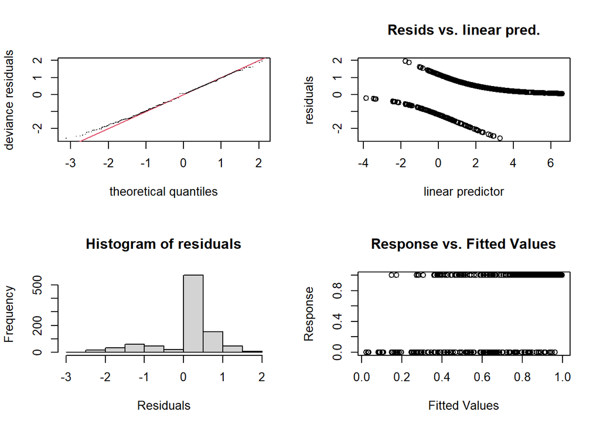

```
##
## Method: REML   Optimizer: outer newton
## full convergence after 13 iterations.
## Gradient range [-5.112826e-05,8.448452e-06]
## (score 312.9422 & scale 1).
## Hessian positive definite, eigenvalue range [6.540159e-06,2.140766].
## Model rank =  368 / 368
##
## Basis dimension (k) checking results. Low p-value (k-index<1) may
## indicate that k is too low, especially if edf is close to k'.
##
##                                            k'      edf k-index p-value
## s(Locality)                          8.00e+00 9.88e-01      NA      NA
## s(jnight):HabitatMeteorologicalTower 8.90e+01 1.17e-04    1.01    0.89
## s(jnight):HabitatNatural             8.90e+01 1.13e+00    1.01    0.86
## s(jnight):HabitatTurbinePad          8.90e+01 4.37e+00    1.01    0.90
## s(temp_mean)                         9.00e+00 2.86e+00    1.02    0.92
## s(wind_mean)                         9.00e+00 1.89e+00    1.00    0.80
## ti(temp_mean,wind_mean)              7.20e+01 2.41e+01    0.91    0.01 **
## ---
## Signif. codes:  0 '***' 0.001 '**' 0.01 '*' 0.05 '.' 0.1 ' ' 1
```

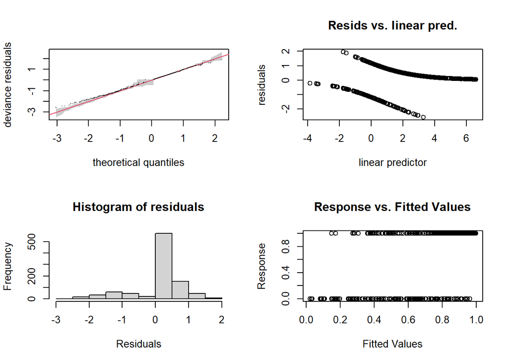

```
##
## Method: REML   Optimizer: outer newton
## full convergence after 13 iterations.
## Gradient range [-5.112826e-05,8.448452e-06]
## (score 312.9422 & scale 1).
## Hessian positive definite, eigenvalue range [6.540159e-06,2.140766].
## Model rank =  368 / 368
##
## Basis dimension (k) checking results. Low p-value (k-index<1) may
## indicate that k is too low, especially if edf is close to k'.
##
##                                            k'      edf k-index p-value
## s(Locality)                          8.00e+00 9.88e-01      NA      NA
## s(jnight):HabitatMeteorologicalTower 8.90e+01 1.17e-04    1.01    0.92
## s(jnight):HabitatNatural             8.90e+01 1.13e+00    1.01    0.85
## s(jnight):HabitatTurbinePad          8.90e+01 4.37e+00    1.01    0.90
## s(temp_mean)                         9.00e+00 2.86e+00    1.02    0.96
## s(wind_mean)                         9.00e+00 1.89e+00    1.00    0.80
## ti(temp_mean,wind_mean)              7.20e+01 2.41e+01    0.91    0.01 **
## ---
## Signif. codes:  0 '***' 0.001 '**' 0.01 '*' 0.05 '.' 0.1 ' ' 1
```

```
## [1] 0.5971965
```

# Basis dimension (k) checking results:

# m5

### Prune the dataset

```
##
## Family: binomial
## Link function: logit
##
## Formula:
## cbind(yes_batpass, no_batpass) ~ s(Locality, bs = "re") + s(jnight,
##     by = Habitat, bs = "gp", k = 90) + Habitat + s(temp_mean) +
##     s(wind_mean) + ti(temp_mean, wind_mean, k = c(15, 15))
##
## Parametric coefficients:
##                   Estimate Std. Error z value Pr(>|z|)
## (Intercept)         3.3114     0.5073   6.527 6.69e-11 ***
## HabitatTurbinePad   0.5369     0.4275   1.256    0.209
## ---
## Signif. codes:  0 '***' 0.001 '**' 0.01 '*' 0.05 '.' 0.1 ' ' 1
##
## Approximate significance of smooth terms:
##                                edf Ref.df Chi.sq  p-value
## s(Locality)                  1.340      6  1.598   0.2994
## s(jnight):HabitatNatural     1.917     87  5.047   0.0132 *
## s(jnight):HabitatTurbinePad  4.216     88 26.370  < 2e-16 ***
## s(temp_mean)                 2.918      9 19.002 1.75e-06 ***
## s(wind_mean)                 3.425      9 15.482 4.41e-05 ***
## ti(temp_mean,wind_mean)     27.232     72 76.375  < 2e-16 ***
## ---
## Signif. codes:  0 '***' 0.001 '**' 0.01 '*' 0.05 '.' 0.1 ' ' 1
##
## R-sq.(adj) =  0.503   Deviance explained = 54.6%
## -REML = 211.39  Scale est. = 1         n = 811
```

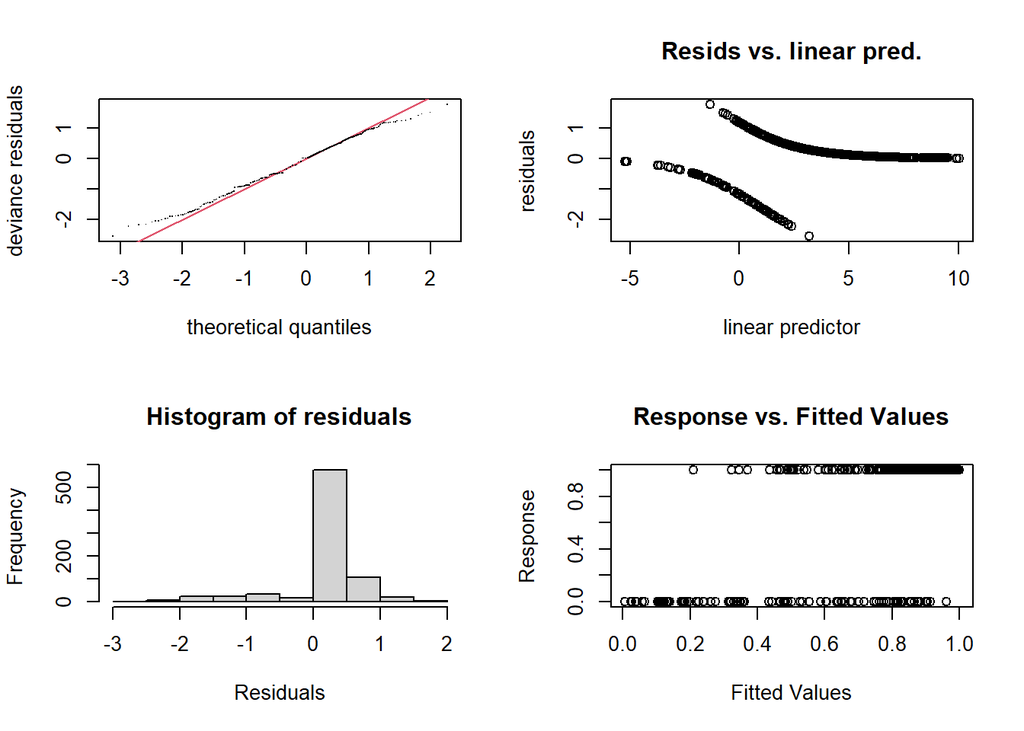

```
##
## Method: REML   Optimizer: outer newton
## full convergence after 12 iterations.
## Gradient range [-5.428416e-05,3.214907e-05]
## (score 211.3931 & scale 1).
## Hessian positive definite, eigenvalue range [1.702042e-06,2.493665].
## Model rank =  277 / 277
##
## Basis dimension (k) checking results. Low p-value (k-index<1) may
## indicate that k is too low, especially if edf is close to k'.
##
##                                k'   edf k-index p-value
## s(Locality)                  7.00  1.34      NA      NA
## s(jnight):HabitatNatural    89.00  1.92    1.05    0.99
## s(jnight):HabitatTurbinePad 89.00  4.22    1.05    0.99
## s(temp_mean)                 9.00  2.92    1.05    0.99
## s(wind_mean)                 9.00  3.42    1.05    0.99
## ti(temp_mean,wind_mean)     72.00 27.23    0.97    0.46
```

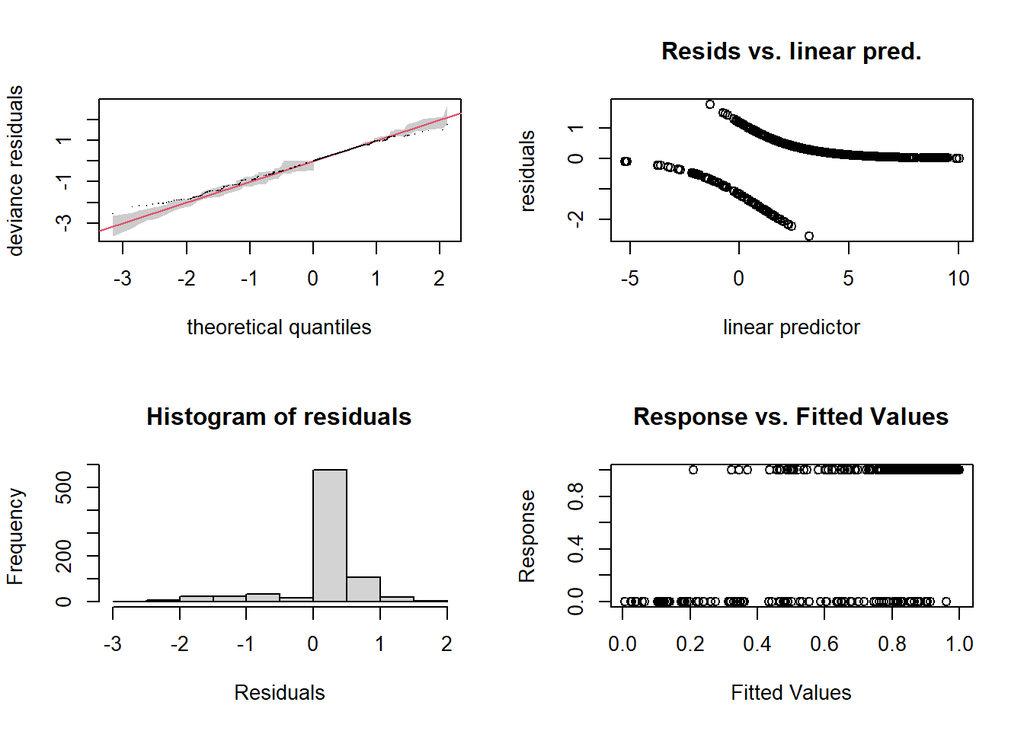

```
##
## Method: REML   Optimizer: outer newton
## full convergence after 12 iterations.
## Gradient range [-5.428416e-05,3.214907e-05]
## (score 211.3931 & scale 1).
## Hessian positive definite, eigenvalue range [1.702042e-06,2.493665].
## Model rank =  277 / 277
##
## Basis dimension (k) checking results. Low p-value (k-index<1) may
## indicate that k is too low, especially if edf is close to k'.
##
##                                k'   edf k-index p-value
## s(Locality)                  7.00  1.34      NA      NA
## s(jnight):HabitatNatural    89.00  1.92    1.05    0.99
## s(jnight):HabitatTurbinePad 89.00  4.22    1.05    0.99
## s(temp_mean)                 9.00  2.92    1.05    0.98
## s(wind_mean)                 9.00  3.42    1.05    0.99
## ti(temp_mean,wind_mean)     72.00 27.23    0.97    0.56
```

```
## [1] 0.3749742
```

# Basis dimension (k) checking results:

# m6

### dataset does not include the met tower

### otherwise, the same model as m1

```
##
## Family: binomial
## Link function: logit
##
## Formula:
## cbind(yes_batpass, no_batpass) ~ s(Locality, bs = "re") + s(jnight,
##     by = Habitat, bs = "gp", k = 90) + Habitat + s(temp_mean) +
##     s(wind_mean) + ti(temp_mean, wind_mean)
##
## Parametric coefficients:
##                   Estimate Std. Error z value Pr(>|z|)
## (Intercept)         4.9092     2.2112   2.220   0.0264 *
## HabitatTurbinePad   0.6166     0.4621   1.334   0.1821
## ---
## Signif. codes:  0 '***' 0.001 '**' 0.01 '*' 0.05 '.' 0.1 ' ' 1
##
## Approximate significance of smooth terms:
##                               edf Ref.df Chi.sq  p-value
## s(Locality)                 1.685      6  2.192   0.2480
## s(jnight):HabitatNatural    2.586     86  7.709   0.0219 *
## s(jnight):HabitatTurbinePad 5.084     87 36.285 1.51e-06 ***
## s(temp_mean)                6.249      9 32.676  < 2e-16 ***
## s(wind_mean)                5.413      9 27.644 1.65e-06 ***
## ti(temp_mean,wind_mean)     2.427     16 22.714 1.26e-06 ***
## ---
## Signif. codes:  0 '***' 0.001 '**' 0.01 '*' 0.05 '.' 0.1 ' ' 1
##
## R-sq.(adj) =  0.415   Deviance explained = 44.4%
## -REML = 228.76  Scale est. = 1         n = 811
```

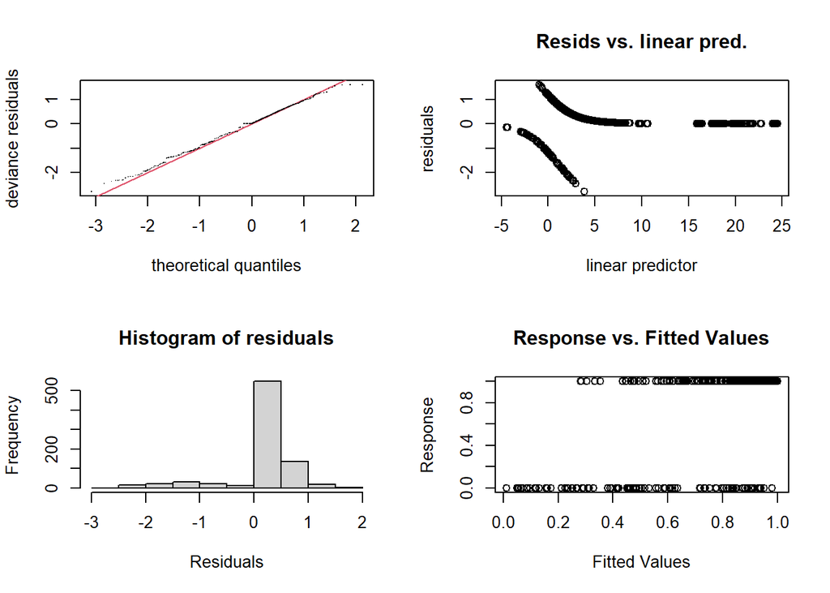

```
##
## Method: REML   Optimizer: outer newton
## full convergence after 16 iterations.
## Gradient range [-8.270666e-05,7.882422e-05]
## (score 228.7632 & scale 1).
## Hessian positive definite, eigenvalue range [2.683698e-06,1.305434].
## Model rank =  221 / 221
##
## Basis dimension (k) checking results. Low p-value (k-index<1) may
## indicate that k is too low, especially if edf is close to k'.
##
##                                k'   edf k-index p-value
## s(Locality)                  7.00  1.69      NA      NA
## s(jnight):HabitatNatural    89.00  2.59    0.91   0.035 *
## s(jnight):HabitatTurbinePad 89.00  5.08    0.91   0.025 *
## s(temp_mean)                 9.00  6.25    0.91   0.040 *
## s(wind_mean)                 9.00  5.41    0.90   0.005 **
## ti(temp_mean,wind_mean)     16.00  2.43    0.83  <2e-16 ***
## ---
## Signif. codes:  0 '***' 0.001 '**' 0.01 '*' 0.05 '.' 0.1 ' ' 1
```

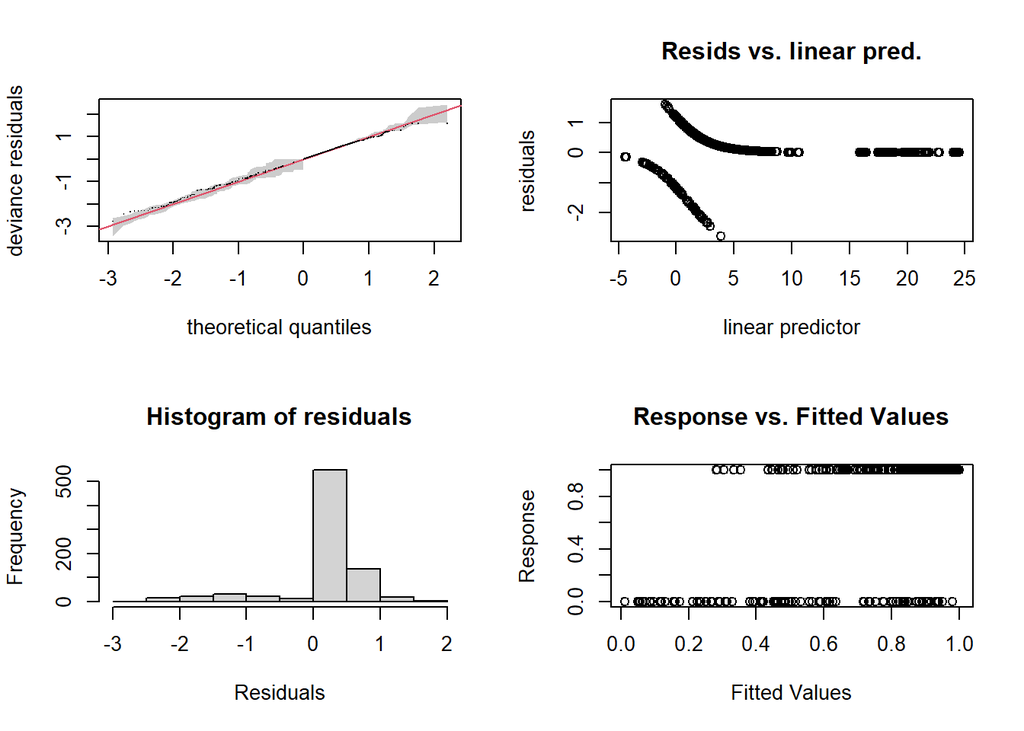

```
##
## Method: REML   Optimizer: outer newton
## full convergence after 16 iterations.
## Gradient range [-8.270666e-05,7.882422e-05]
## (score 228.7632 & scale 1).
## Hessian positive definite, eigenvalue range [2.683698e-06,1.305434].
## Model rank =  221 / 221
##
## Basis dimension (k) checking results. Low p-value (k-index<1) may
## indicate that k is too low, especially if edf is close to k'.
##
##                                k'   edf k-index p-value
## s(Locality)                  7.00  1.69      NA      NA
## s(jnight):HabitatNatural    89.00  2.59    0.91   0.030 *
## s(jnight):HabitatTurbinePad 89.00  5.08    0.91   0.025 *
## s(temp_mean)                 9.00  6.25    0.91   0.025 *
## s(wind_mean)                 9.00  5.41    0.90   0.025 *
## ti(temp_mean,wind_mean)     16.00  2.43    0.83  <2e-16 ***
## ---
## Signif. codes:  0 '***' 0.001 '**' 0.01 '*' 0.05 '.' 0.1 ' ' 1
```

```
## [1] 0.5615471
```

# Basis dimension (k) checking results:

# m7

### dataset does not include the met tower

### otherwise, remove adjust k term in the 3 night by habitat term

```
##
## Family: binomial
## Link function: logit
##
## Formula:
## cbind(yes_batpass, no_batpass) ~ s(Locality, bs = "re") + s(jnight,
##     by = Habitat, bs = "gp") + Habitat + s(temp_mean) + s(wind_mean) +
##     ti(temp_mean, wind_mean)
##
## Parametric coefficients:
##                   Estimate Std. Error z value Pr(>|z|)
## (Intercept)         2.7783     0.2671  10.400   <2e-16 ***
## HabitatTurbinePad   0.6229     0.4391   1.418    0.156
## ---
## Signif. codes:  0 '***' 0.001 '**' 0.01 '*' 0.05 '.' 0.1 ' ' 1
##
## Approximate significance of smooth terms:
##                                edf Ref.df Chi.sq  p-value
## s(Locality)                 1.3965      6  1.719 0.280553
## s(jnight):HabitatNatural    2.0686     11  6.138 0.031141 *
## s(jnight):HabitatTurbinePad 4.6336     11 36.984  < 2e-16 ***
## s(temp_mean)                0.9543      9 18.662 1.89e-06 ***
## s(wind_mean)                3.7346      9 35.613  < 2e-16 ***
## ti(temp_mean,wind_mean)     2.2593     16 14.002 0.000112 ***
## ---
## Signif. codes:  0 '***' 0.001 '**' 0.01 '*' 0.05 '.' 0.1 ' ' 1
##
## R-sq.(adj) =  0.359   Deviance explained = 37.3%
## -REML = 226.05  Scale est. = 1         n = 811
```

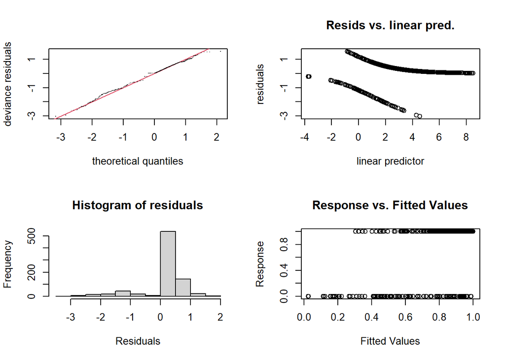

```
##
## Method: REML   Optimizer: outer newton
## full convergence after 15 iterations.
## Gradient range [-5.039703e-05,1.13311e-05]
## (score 226.0539 & scale 1).
## Hessian positive definite, eigenvalue range [9.407434e-07,0.7386722].
## Model rank =  65 / 65
##
## Basis dimension (k) checking results. Low p-value (k-index<1) may
## indicate that k is too low, especially if edf is close to k'.
##
##                                 k'    edf k-index p-value
## s(Locality)                  7.000  1.397      NA      NA
## s(jnight):HabitatNatural    11.000  2.069    0.86  <2e-16 ***
## s(jnight):HabitatTurbinePad 11.000  4.634    0.86  <2e-16 ***
## s(temp_mean)                 9.000  0.954    0.85  <2e-16 ***
## s(wind_mean)                 9.000  3.735    0.84  <2e-16 ***
## ti(temp_mean,wind_mean)     16.000  2.259    0.76  <2e-16 ***
## ---
## Signif. codes:  0 '***' 0.001 '**' 0.01 '*' 0.05 '.' 0.1 ' ' 1
```

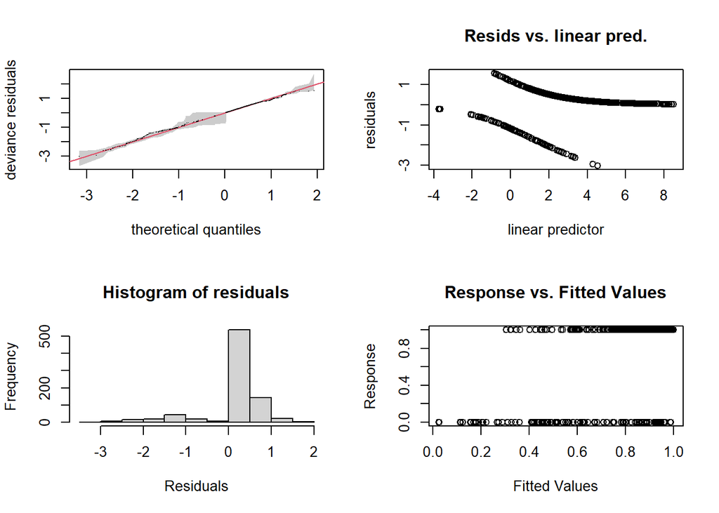

```
##
## Method: REML   Optimizer: outer newton
## full convergence after 15 iterations.
## Gradient range [-5.039703e-05,1.13311e-05]
## (score 226.0539 & scale 1).
## Hessian positive definite, eigenvalue range [9.407434e-07,0.7386722].
## Model rank =  65 / 65
##
## Basis dimension (k) checking results. Low p-value (k-index<1) may
## indicate that k is too low, especially if edf is close to k'.
##
##                                 k'    edf k-index p-value
## s(Locality)                  7.000  1.397      NA      NA
## s(jnight):HabitatNatural    11.000  2.069    0.86   0.005 **
## s(jnight):HabitatTurbinePad 11.000  4.634    0.86  <2e-16 ***
## s(temp_mean)                 9.000  0.954    0.85  <2e-16 ***
## s(wind_mean)                 9.000  3.735    0.84  <2e-16 ***
## ti(temp_mean,wind_mean)     16.000  2.259    0.76  <2e-16 ***
## ---
## Signif. codes:  0 '***' 0.001 '**' 0.01 '*' 0.05 '.' 0.1 ' ' 1
```

```
## [1] 0.826536
```

# Basis dimension (k) checking results:

# What did we learn?

Making a higher k value can help with improving the model fit but it tends to lead to underdispersion in this case. Removing the met tower data makes the models easier to work with.

To Address under dispersion in binary GAMs:

https://dergipark.org.tr/en/download/article-file/922496 This article suggests using an extended Altham distribution (EAD) family for under dispersed binomial count data- however I cannot find any commands in the mgcv package that will allow me to call that distribution.

The MM package does have the option to use this family but before changing packages, it is perhaps wiser to try and use counts as a response variable

https://cran.r-project.org/web/packages/MM/vignettes/Gianfranco.pdf

### Notes from meeting with Katrine 29.11.2022

## 1. For the total bat data set, with y = binary nightly bat activity

1. Adjust the k value for the bats_tot model to find one that better suits the data
2. Illustrate the wind/temperature cutoffs.

## At some point, it may be necessary to re-aggregate the weather data to Facility rather than across both facilities